# Advanced R

16. November 2015

R advanced script by Florian Schneider is licensed under a [Creative Commons Attribution 4.0 International License](http://creativecommons.org/licenses/by/4.0/).

## Poll

1. recap: objects and functions *
2. file handling: save and load data from/to file
3. data crunching: subset and transform data (e.g. tapply) *
4. conditions and loops: if, for, while, lapply *
5. **build your plot: multi-panel layouts, labels, colors** ***
6. **output for production: dynamic reports and tables in word and pdf** ***
7. best practices for coding: version control, documentation, open source

## The problem: simplify computational workflow

A defined workflow:

- is easy to reproduce plots and tables if the data change
- is easy to reproduce by collaborators, reviewers and your future self
- is robust against data errors: figures, tables and analysis are based on the same raw data
- is easy to publish (open source)

## A reproducible workflow example

1. read raw sampling data from file "rawdata.csv"
2. read supplementary plot information from "plots.csv"
3. eliminate irrelevant columns and rows from "rawdata.csv"
4. calculate some descriptive statistics for rows in "plots.csv" and merge to rawdata. Save as "data.Rd"
5. perform statistical test on "data.Rd" and save summary output table to "stats.Rd"
6. generate plot from "data.Rd" that shows the raw data distribution and save to "fig1.pdf"
7. generate plot visualising the statistical test (5.) and save to "fig2.pdf"
8. embed figures and table, as well as values from statistics in manuscript.

## learn along the way

- recap: what are objects and functions in R?
- load data and save output
- composing a plot: multi-panel layouts, labels, colors
- output for production: dynamic reports and tables in word and pdf

sorry, no time for

- calculate summary data from data tables using tapply
- loops with `for()` and `while()`

## recap: Functions

Input -> FUNCTION -> output

```r
function(x, ... )
```

see the manual for any function by calling `help()` or `?`, e.g.

```r
?lm
```

## recap: Functions

Define an own function

```r
add_one_to <- function(x) {
       x+1
}

a <- c(0.23,0.53,0.42,0.75,0.26)
add_one_to(a)
```

```
## [1] 1.23 1.53 1.42 1.75 1.26
```

## 1. read in raw data

## raw-data structure

**Do:**

- **one line = one data point**
- **save measured raw data**, no transformed or derived data
- **save in .csv or .txt format**, not .xxls

**Don't**

- merge cells
- put replicates in the same row
- put different treatments in the same row
- keep empty lines (missing data values are okay!)

## Column names

- unique within the table
- unambiguous and easy to remember
- use either only lower case *or* only upper case letters
- no spaces or points or special characters, except`_`
- english

## read raw data

```r
rawdata <- read.table("rawdata.csv", header = TRUE, sep = ",", dec = ".")
rawdata <- read.csv2("rawdata.csv", sep = ",", dec = "." )
rawdata <- read.csv("rawdata.csv")
```

## Exercise 1

## Exercise 1

We are assuming an experiment:

- 12 grassland plots of varying land use intensity
- The amount of fertilization, frequency of grazing by cattle and mowing are documented for each plot.
- temperature and precipitation
- On four subplots, insect diversity is assessed
- two subplots are fenced against grazing by large herbivores
- Sampling was done in two years (2013,2014)

## Exercise 1

- read data tables: "rawdata.csv" and "plots.csv"

## Exercise 1

- read data tables: "rawdata.csv" and "plots.csv"

```r
setwd("C:/path/to/workingdirectory")
```

```r
rawdata <- read.csv("rawdata.csv")
plots <- read.csv("plots.csv")
```

Tipp: Use RStudio projects!

## recap: object classes

## recap: object classes

**[Excurse: Objects](https://dl.dropboxusercontent.com/u/4625163/AdvancedR/objects.html)**

## 2. data handling

## select data columns I

`attach()` and `detach()`

```r
str(rawdata)
attach(rawdata)
plot(shannon ~ fenced)
detach(rawdata)
```

**Using `attach()` is considered bad practice!**

## select data columns II

The `$` or `[]` selector

```r
lm(rawdata$shannon ~  rawdata$fenced)
```

or,

```r
shannon <- rawdata$shannon
fenced <- rawdata$fenced
lm(shannon ~ fenced)
```

## select data columns III

`with()` environment

```r
with(rawdata, lm(shannon ~ fenced))
```

## select data columns IV

**Best practice advice:** use the `data` parameter

```r
lm(shannon ~ fenced, data = rawdata)
```

## select data rows I

```r
data1 <- rawdata[-c(42)]
data1 <- rawdata[-c(42:64)]
```

## select data rows II

'logical expressions'

- `A == B`
- `A != B`
- `A < B`, `A > B`
- `A <= B`, `A >= B`
- `A %in% B`

return logical values: `TRUE` or `FALSE`

## select data rows II

```r
1:10 > 6
```

```
##  [1] FALSE FALSE FALSE FALSE FALSE FALSE  TRUE  TRUE  TRUE  TRUE
```

```r
f <- as.factor(c("A", "A", "B", "C", "A", "B", "B", "C", "C"))
f == "A"
```

```
## [1]  TRUE  TRUE FALSE FALSE  TRUE FALSE FALSE FALSE FALSE
```

```r
6 %in% 1:5
```

```
## [1] FALSE
```

```r
c("SCH", "HAI", "ALB") %in% c("HAI")
```

```
## [1] FALSE  TRUE FALSE
```

## select data rows II

select rows from a data table:

```r
d <- data.frame(x = f, y = c(1,1,1.4,1.2,1.3,1.2,1.4,1.2,1.1))
d[d$x == "C",]
```

```
##   x   y
## 4 C 1.2
## 8 C 1.2
## 9 C 1.1
```

```r
d[d$y >= 1.3,]
```

```
##   x   y
## 3 B 1.4
## 5 A 1.3
## 7 B 1.4
```

## select data rows II

use the `subset()` function

```r
subset(d, x == "C")
```

```
##   x   y
## 4 C 1.2
## 8 C 1.2
## 9 C 1.1
```

```r
subset(d, y >= 1.3)
```

```
##   x   y
## 3 B 1.4
## 5 A 1.3
## 7 B 1.4
```

## select data rows II

**A side note on factor levels:** If you want to eliminate factor levels specify the argument `drop = TRUE`:

```r
f[f == "A"]
```

```
## [1] A A A
## Levels: A B C
```

```r
f[f == "A", drop = TRUE]
```

```
## [1] A A A
## Levels: A
```

## Exercise 2

## Exercise 2

1. create a table that contains only the fenced replicates.
2. eliminate flawed data points from rawdata (see column 'notes').
3. Species data for 2014 are not available yet. Eliminate 2014 values from `plots`!
4. merge the plot information of 2013 to the rawdata table. (hint: use `merge()`)
5. save the result as your working data `data.Rd` or `data.csv`.

## Exercise 2

```r
data <- subset(rawdata, notes == "")
plots2013 <- subset(plots, year == "2013")
data <- merge(data, plots2013, by.x = "plot", by.y = "plot")
write.csv(data, "data.csv")
save(data, data, file = "data.Rd")
```

## 3. data analysis

## statistical modelling

```r
model <- lm(shannon ~ grazing * fenced, data = data )
anova(model)
```

```
## Analysis of Variance Table
##
## Response: shannon
##                Df Sum Sq Mean Sq F value    Pr(>F)
## grazing         1 1.3829  1.3829  8.4132  0.005964 **
## fenced          1 7.5658  7.5658 46.0274 3.325e-08 ***
## grazing:fenced  1 0.8901  0.8901  5.4151  0.024981 *
## Residuals      41 6.7394  0.1644
## ---
## Signif. codes:  0 '***' 0.001 '**' 0.01 '*' 0.05 '.' 0.1 ' ' 1
```

## many things

### I will not cover today

How to aggregate and transform data

- `apply()`
- `tapply()`
- `for()` loops
- package `plyr` and `dplyr`

please look up documentations and help files.

## 4. Plotting

## high-level vs. low-level commands

**high-level**: create a new plot

**low-level**: add something to an existing plot

**graphical parameters**: set the stage/canvas

## examples: high-level

scatterplots: `plot()`

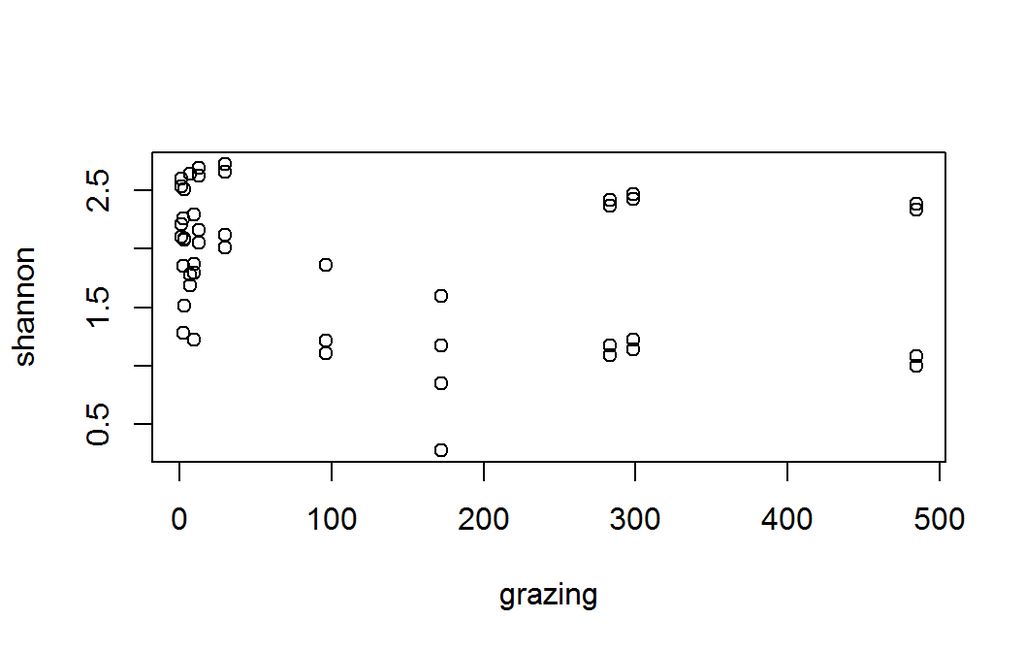

```r
plot(shannon ~ grazing, data = data)
```

## examples: high-level

- line plots: `plot(..., type = "l")`

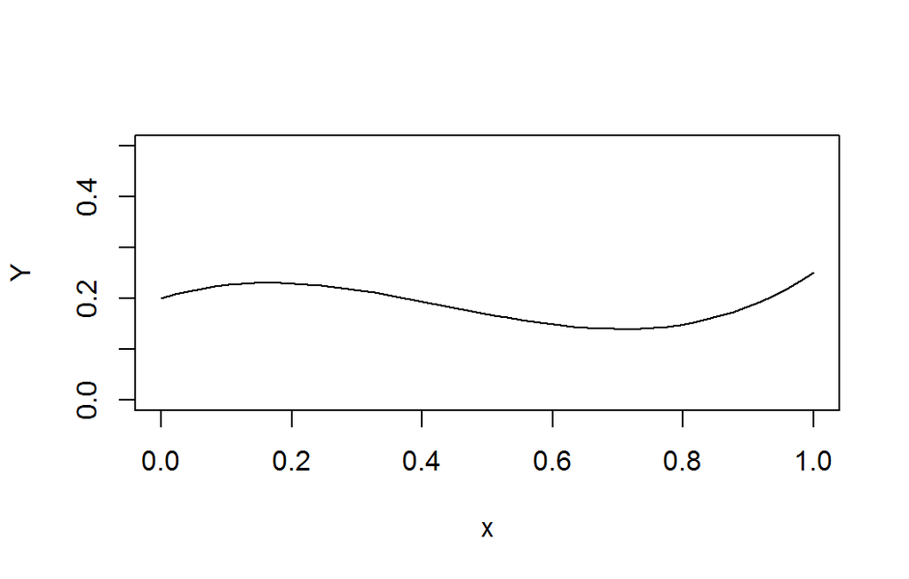

```r
plot(x, y, type = "l", ylab = "Y", xlab = "x",  ylim = c(0,0.5))
```

## examples: high-level

- boxplots: `boxplot()`

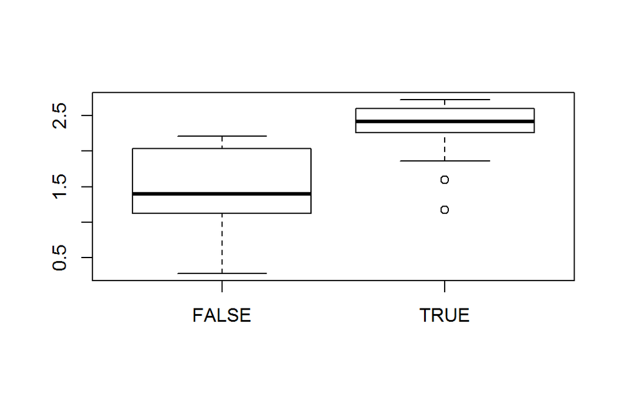

```r
boxplot(shannon ~ fenced, data = data)
```

## examples: high-level

- histograms: `hist()`

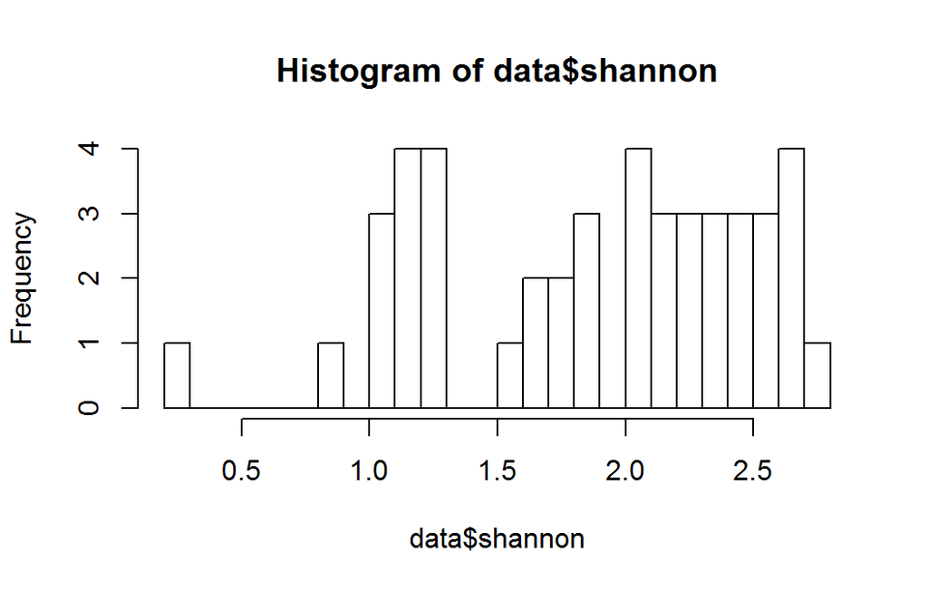

```r
hist(data$shannon, breaks = 24)
```

## examples: high-level

- 3D perspective plots: `persp()`

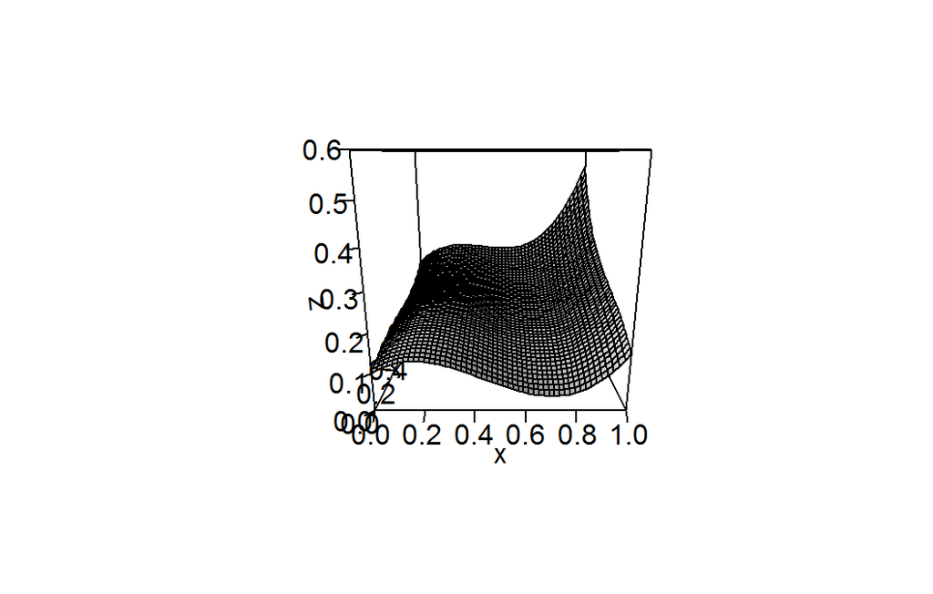

```r
persp(x,y,z, ticktype = "detailed", zlim = c(0,0.6), shade = 0.4)
```

## high-level plot options

- **plotting region**: axis limits (`xlim` and `ylim`, `xaxs` and `yaxs`), boxtype (`bty`) and background (`bg`), fix aspect ratio (`asp`)
- **axis style**: logarithmic plotting (`log = "xy"`), axis label orientation (`las`), font size (`cex.axis`), specify tick mark labels (`labels`), tick mark position (`xaxp` and `yaxp`) , tick length (`tck`)
- **text labels**: axis labels (`ylab` and `xlab`), plot titles (`main` and `sub`)
- **point formatting**: point size (`cex`), point character (`pch`), colors (`col` and `fg`)
- **line formatting**: line type (`lty`) and line width (`lwd`), colors (`col`)

look up `?par` and plot specific help files.

## examples: low-level

- `points()`

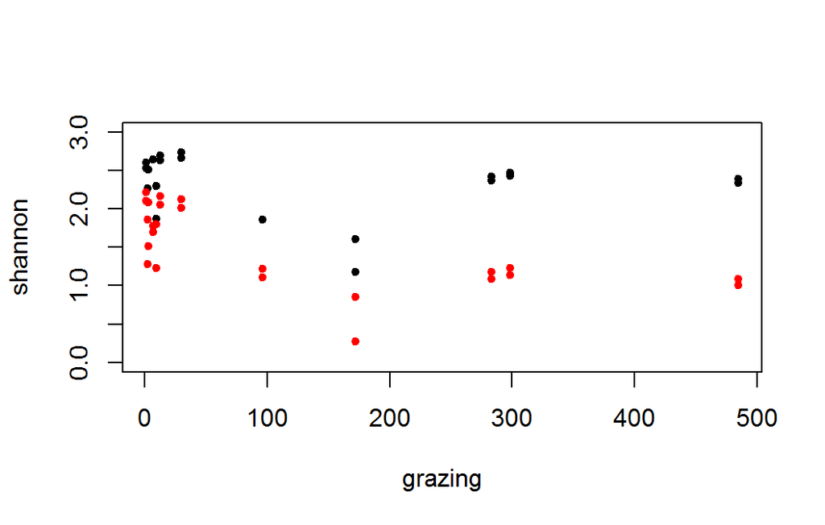

## examples: low-level

- lines: `abline()` and `lines()`

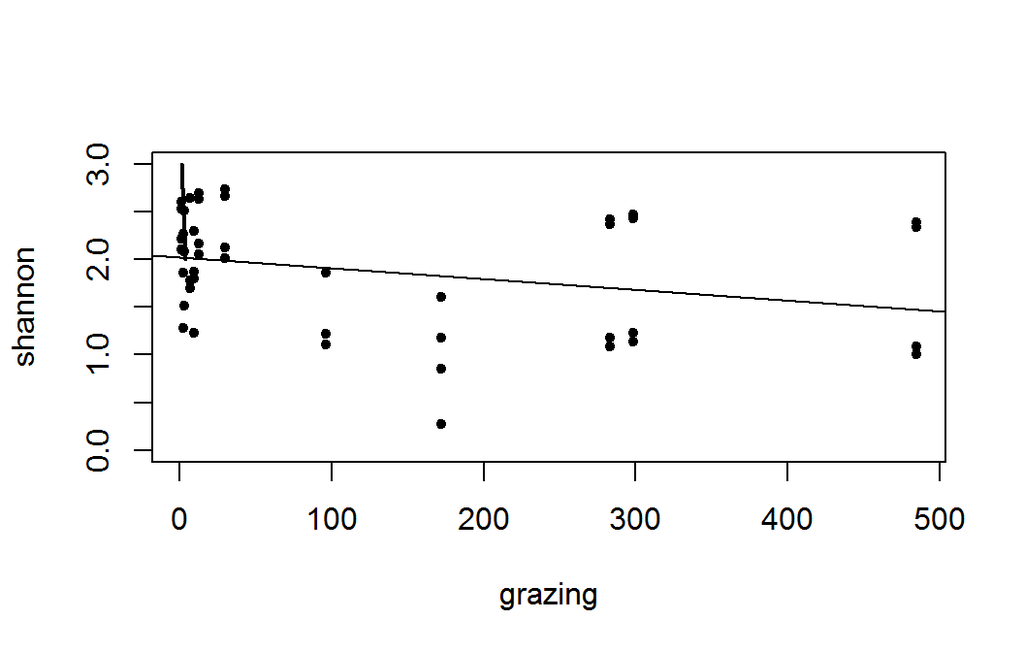

## examples: low-level

- `axis()`

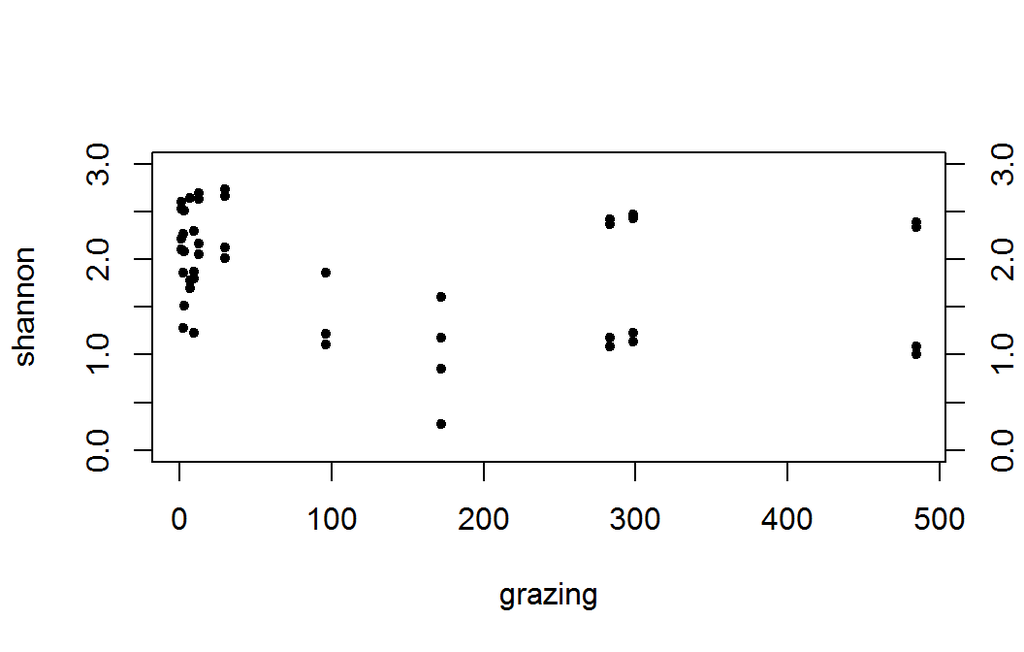

## examples: low-level

- `legend()`

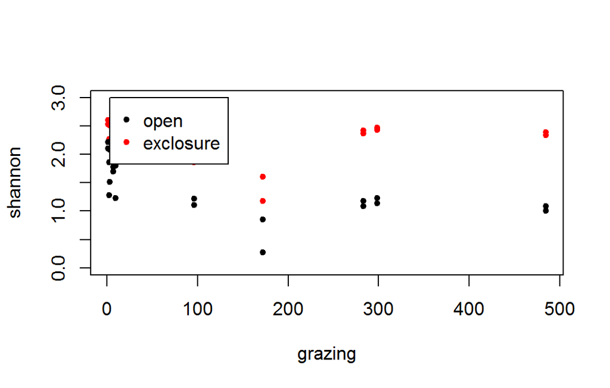

## low-level options

- same as for high-level
- `xpd`: plot outside of plotting region.

look up `?par` and function help files.

## graphical parameters

Highest level of definitions

```r
par(...)
```

## graphical parameters

- outer and inner margins (bottom, left, upper, right)

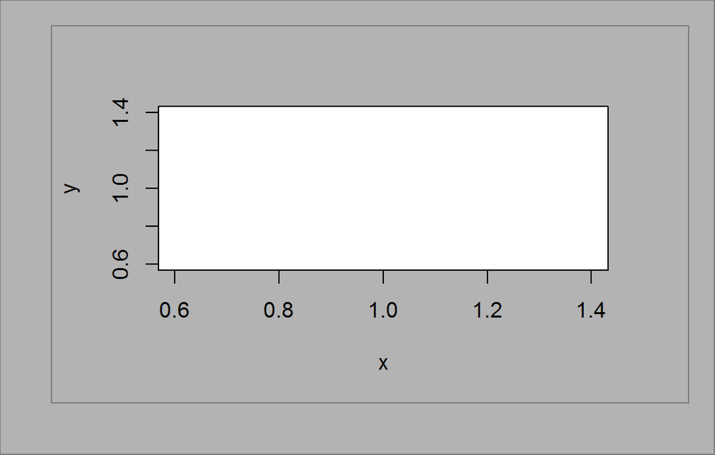

```r
par(mar = c(5,4,3,3)+0.1, oma = c(2,2,1,1))
plot(x,y, ...)
```

## graphical parameters

- multi-panel grid

```r
par(mfrow = c(2,2))
plot(x,y, ...)
plot(x,y, ...)
plot(x,y, ...)
plot(x,y, ...)
```

## graphical parameters

- multi-panel grid

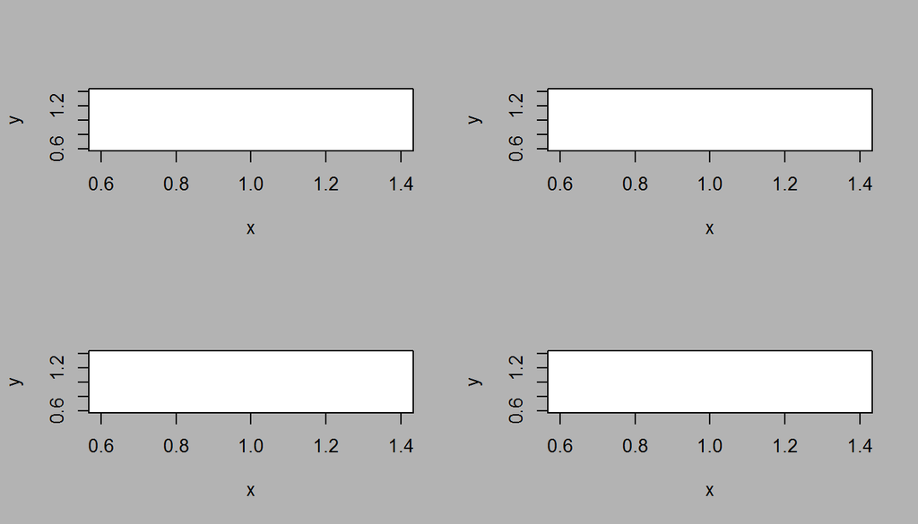

## Examples

## format points

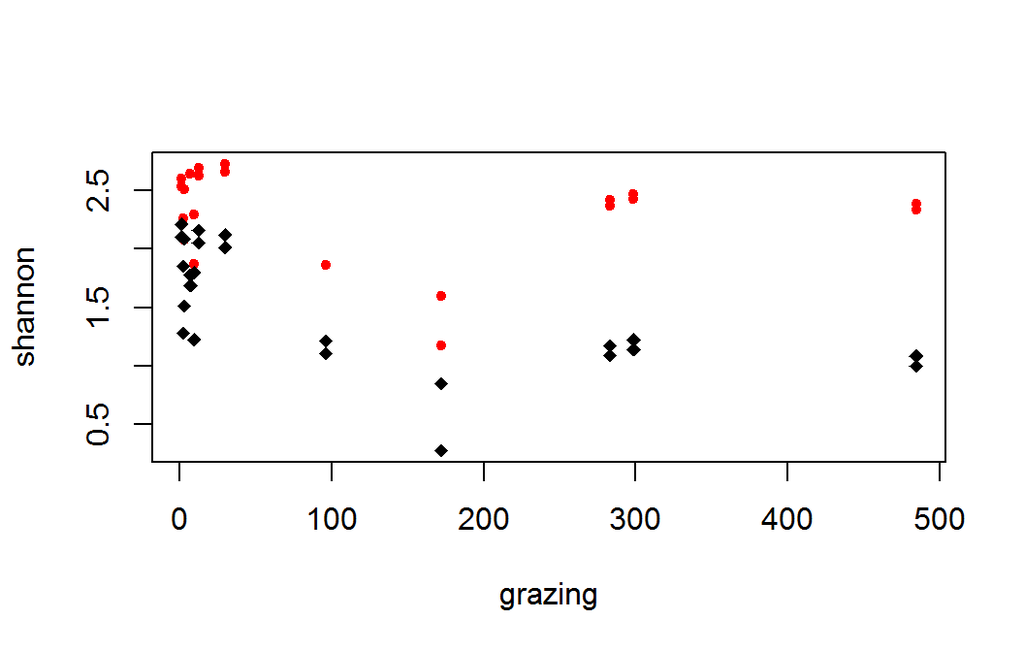

```r
plot(shannon ~ grazing, data = data,
     pch = c(18,20)[fenced+1],
     col = c( "black", "red")[fenced+1]
     )
```

## format points

Tipps:

- `pch` can be characters: `pch = c("A","B")`
- use filled characters (diamonds `18` or points `20`) rather than open ones (crosses `3` or `4` or circles `1`)
- use distinctive colors, if any

## format points

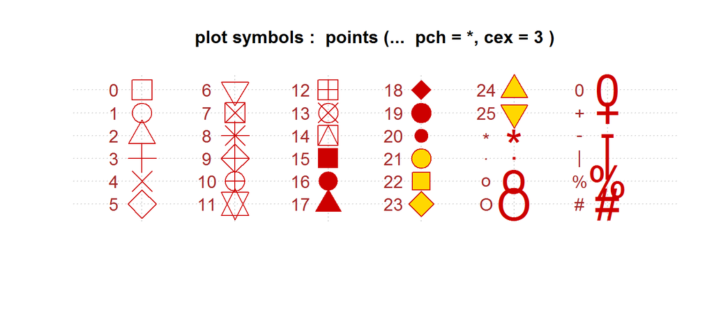

## add model lines

- function `predict()`

```r
model <- lm(shannon ~ grazing * fenced, data = data)
grazing_new <- seq(0, 500, length = 50)
shannon_pred <- predict(model,
                    newdata = list(
                      grazing = grazing_new,
                      fenced = rep(FALSE, 50)
                      ), se.fit = TRUE
                    )
```

## add model lines

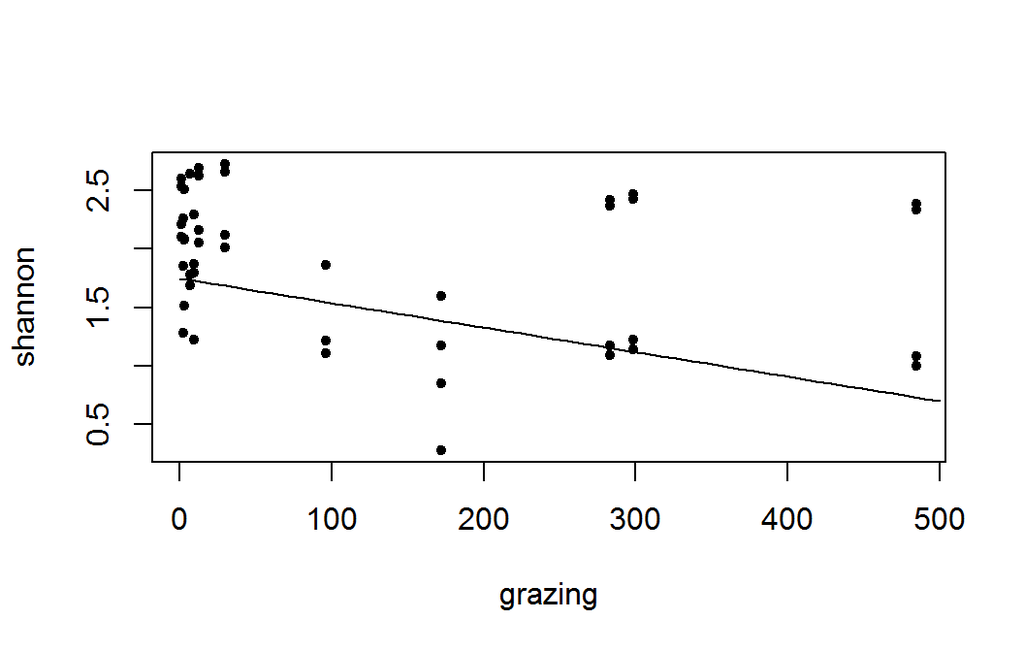

```r
plot(shannon ~ grazing, data = data, pch = 20)
lines(grazing_new, shannon_pred$fit)
```

## add model lines

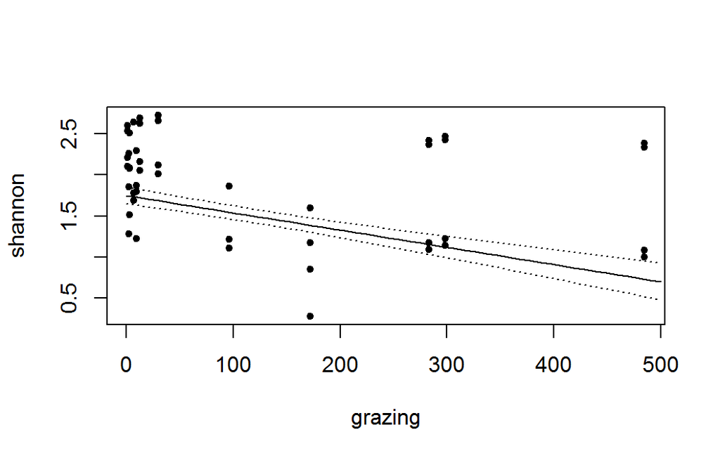

```r
plot(shannon ~ grazing, data = data, pch = 20)
lines(grazing_new, shannon_pred$fit)
lines(grazing_new, shannon_pred$fit + shannon_pred$se.fit, lty = 3)
lines(grazing_new, shannon_pred$fit - shannon_pred$se.fit, lty = 3)
```

## pretty boxplots

- Box plots are noisy:

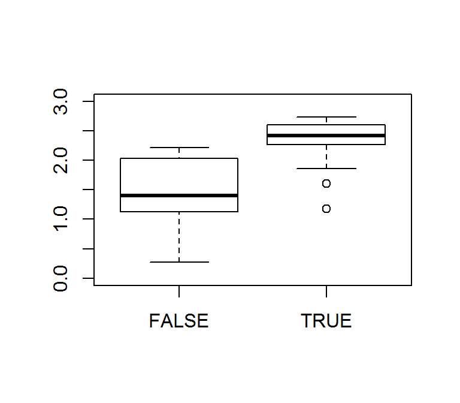

```r
boxplot(shannon ~ fenced, data = data, ylim = c(0,3) )
```

## pretty boxplots

- Box plots are noisy:

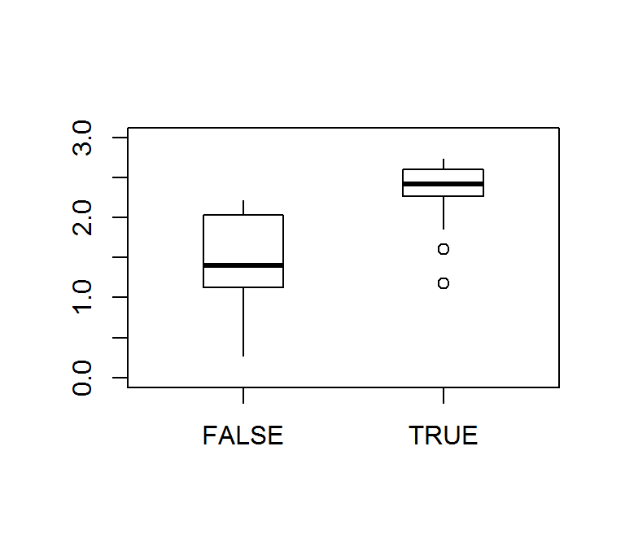

```r
boxplot(shannon ~ fenced, data = data, ylim = c(0,3),
        pars = list(boxwex = 0.4, staplewex = 0,
                    whiskwex = 0, whisklty = 1))
```

## multi-panel layout

- mfrow

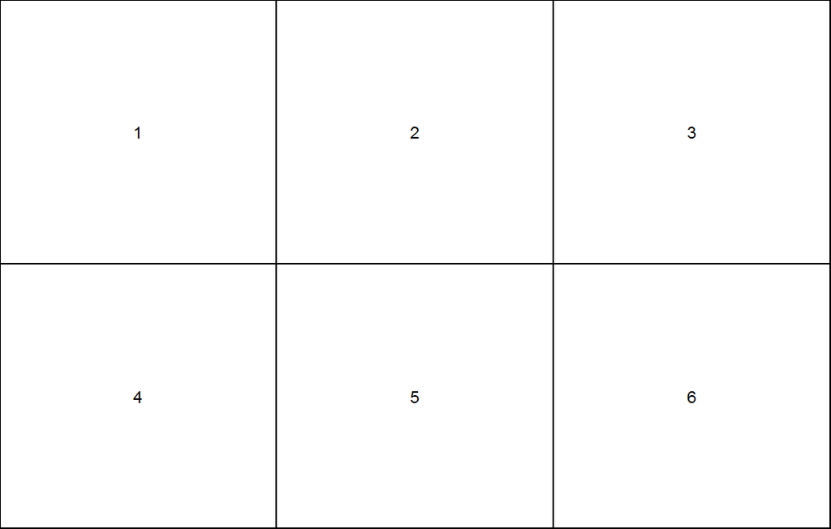

```r
par(mfrow = c(2,3))
layout.show(n = 6)
```

## multi-panel layout

- `layout()`

```r
m <- matrix(c(1,1,1,2,3,6,4,5,6), byrow = TRUE, ncol = 3)
m
```

```
##      [,1] [,2] [,3]
## [1,]    1    1    1
## [2,]    2    3    6
## [3,]    4    5    6
```

## multi-panel layout

- `layout()`

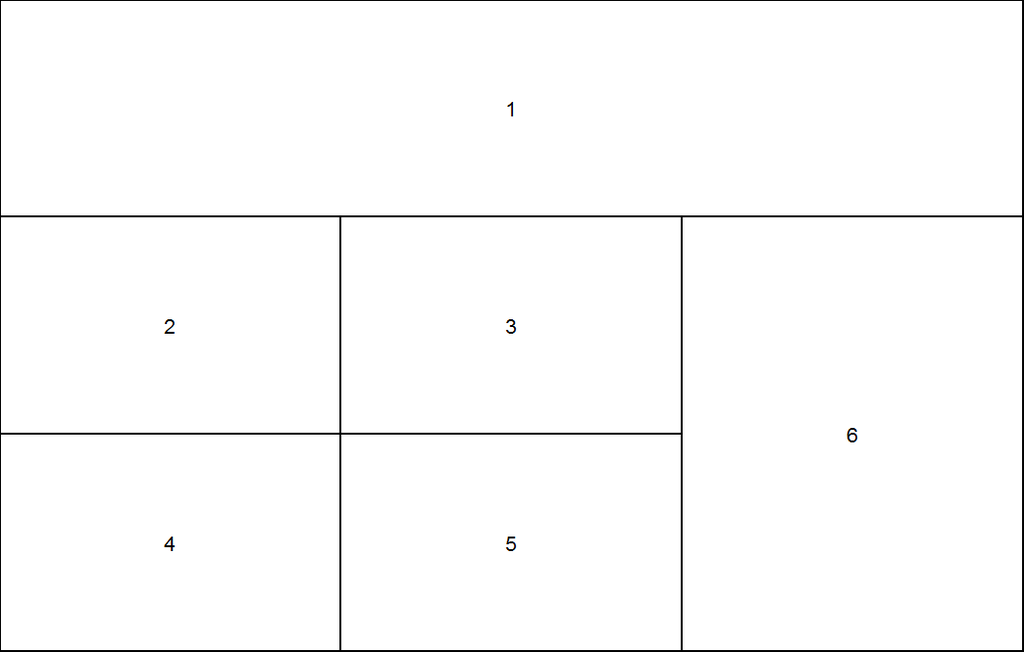

```r
layout(m)
layout.show(n = 6)
```

## multi-panel layout

- `layout()`

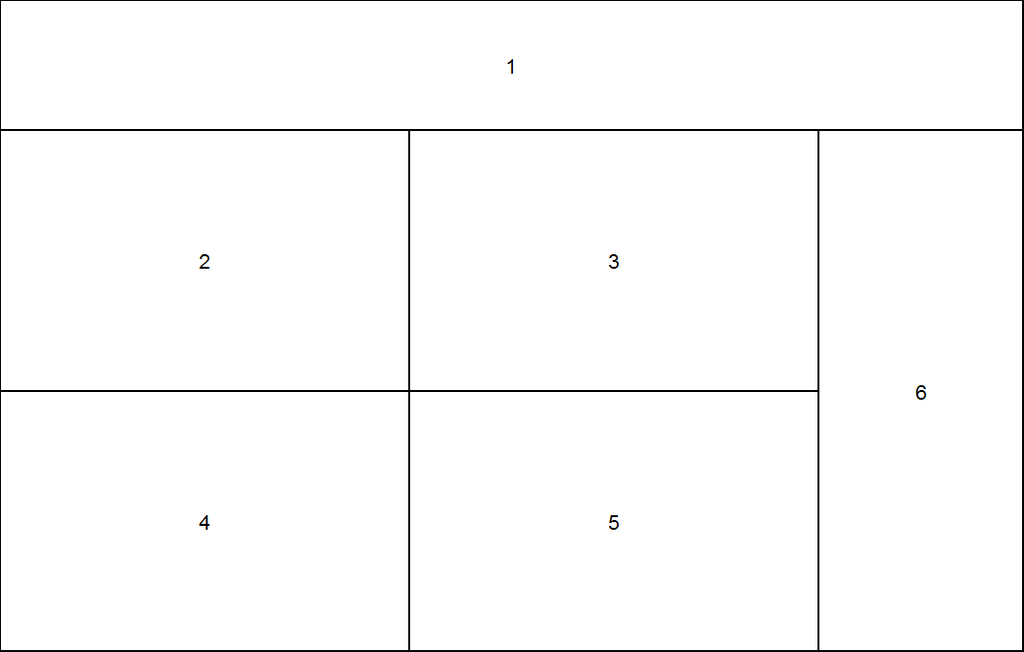

```r
layout(m , height = c(1,2,2), width = c(2,2,1))
layout.show(n = 6)
```

## multi-panel layout

- `layout()` with a complex matrix `m`:

```
##      [,1] [,2] [,3] [,4] [,5] [,6]
## [1,]    1    1    1    5    5    6
## [2,]    1    1    1    5    5    6
## [3,]    1    1    1    1    1    6
## [4,]    1    1    1    1    1    0
## [5,]    1    1    1    1    1    0
## [6,]    2    2    3    3    4    4
```

## multi-panel layout

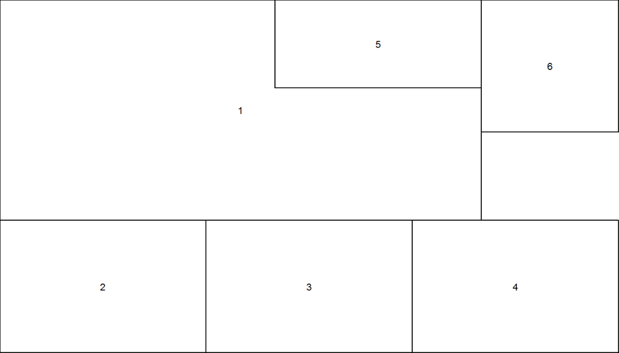

```r
layout(m , height = c(1,1,1,1,1,3), width = c(1,2,1,2,1,2))
layout.show(n = 6)
```

## multi-panel layout

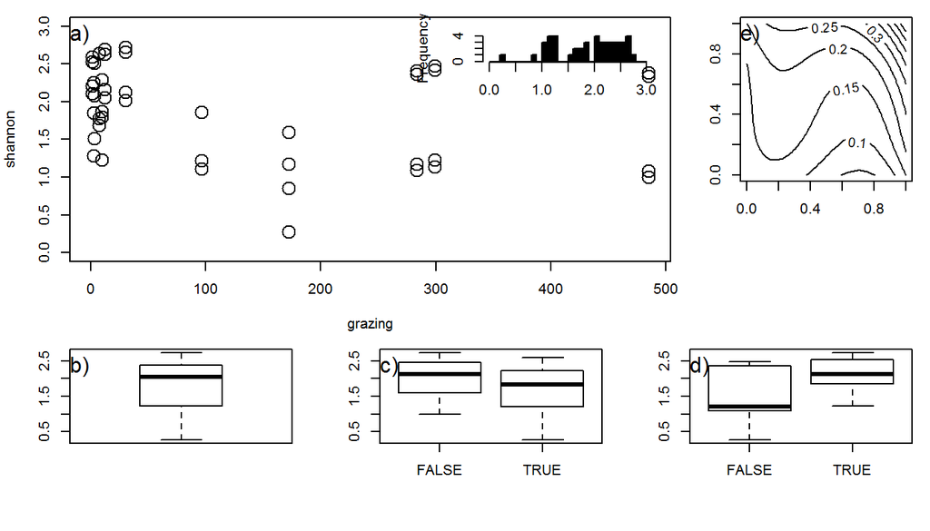

```r
layout(m , height = c(1,1,1,1,1,3), width = c(1,2,1,2,1,2))
# ...
```

## Exercise 4

## Exercise 4

- try to reproduce as many features of this plot as you can:

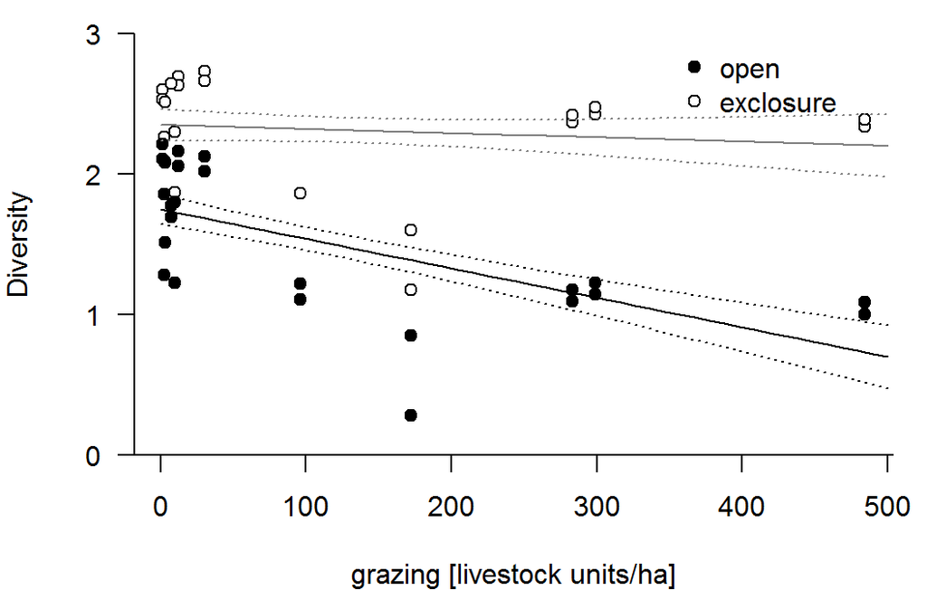

## 5. Production output

## save plots to file

there are different graphics devices:

Raster formats:

- `bmp()` for bitmap files (no compression)
- `png()` for gif and png files (selective color)
- `jpg()` for jpg (pixel compression)
- `tiff()` for tiff files (best quality/compression trade-off)

Use for plots with many (>1000) datapoints or for presentations! use `png()` for black-and-white plots in high-resolution!

## save plots to file

there are different graphics devices:

Vector formats:

- `pdf()` for pdf plotting
- `postscript()` for .eps files

Mostly, this is what journals want, because scalable!

## save plots to file

```r
pdf("filename.pdf",
    width = 7, height = 6,  #in inches: 1in = 2.54cm
    paper = "special",  # or "a4"
    useDingbats = FALSE, # avoids weird symbols
    family = "Times" # for journals that want serif
    )

plot(...)

dev.off()
```

Multiple high-level plots create multi-page pdfs!

## save plots to file

```r
png("filename.png",
    width = 460, height = 720,  #in pixels
    res = 72, # set relative size of plot
    antialias = "none" # no smoothing of pixelation
    family = "Times" # for journals that want serif
    )

plot(...)

dev.off()
```

## Exercise 5

## Exercise 5

- create a .pdf and a .jpg of your previous plot

## dynamic reports with knitr & Rmarkdown

- Markdown input
- R code chunks are evaluated
- automatic bibliography
- latex/pdf and word output

Ideal for documentation of your data exploration:

- mix narrative, code, analysis and figures

RStudio comes with Rmarkdown: http://rmarkdown.rstudio.com/

## Markdown

A simple markup language

```
# Title

## section

text with *italics* and **bold** word highlighting.

- lists
- second point

## section

...
```

## Rmarkdown

Markdown plus R code chunks

see Rmarkdowndemo.Rmd

```r
library(rmarkdown)
render("radvanced/Rmarkdowndemo.Rmd", pdf_document())
```

## output table with knitr

knitr is an R package that turns code to plaintext output.

```r
library(knitr)
kable(anova(model), digits = 3)
```

## output table with knitr

table_demo.Rmd

```r
library(rmarkdown)
render("radvanced/table_demo.Rmd", word_document())
```

## Fin

## Further reading:

- http://adv-r.had.co.nz/ : an online book by Hadley Wickham on realy advanced things
- http://www.rdocumentation.org/ : a collection of manual files for all R packages
- http://rmarkdown.rstudio.com/ : on dynamic reports
- http://www.r-bloggers.com/ : a blog aggregator for all things in R